# Rental Bikes Amount Factors Analysis

Tian Ni

2022-11-26

## Introduction

For this project, given dataset is collected through the Capital bikesharing system of 2011-2012, includes rental bike count, which is interested feature, and other weather and seasonal information. The initial target is to investigate significant factors which would effect the rental bike count, and their importance.

## Data and Setup

#### Data

```
##   instant     dteday season yr mnth holiday weekday workingday weathersit
## 1       1 2011-01-01      1  0    1       0       6          0          2
## 2       2 2011-01-02      1  0    1       0       0          0          2
## 3       3 2011-01-03      1  0    1       0       1          1          1
## 4       4 2011-01-04      1  0    1       0       2          1          1
## 5       5 2011-01-05      1  0    1       0       3          1          1
## 6       6 2011-01-06      1  0    1       0       4          1          1
##       temp    atemp      hum windspeed casual registered  cnt
## 1 0.344167 0.363625 0.805833 0.1604460    331        654  985
## 2 0.363478 0.353739 0.696087 0.2485390    131        670  801
## 3 0.196364 0.189405 0.437273 0.2483090    120       1229 1349
## 4 0.200000 0.212122 0.590435 0.1602960    108       1454 1562
## 5 0.226957 0.229270 0.436957 0.1869000     82       1518 1600
## 6 0.204348 0.233209 0.518261 0.0895652     88       1518 1606
```

Look through the histogram plot of cnt:

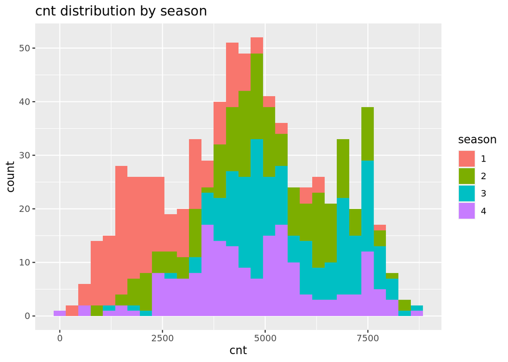

From the plot we can see that cnt follows normal distribution and, in spring(season1), rental bike count mainly lies between 0 and 3000; in summer(season2), fall(season3) and winter(season4), rental bike count mainly lies between 4000 and 6500.

Below is the rental bike count plot by different weather condition level:

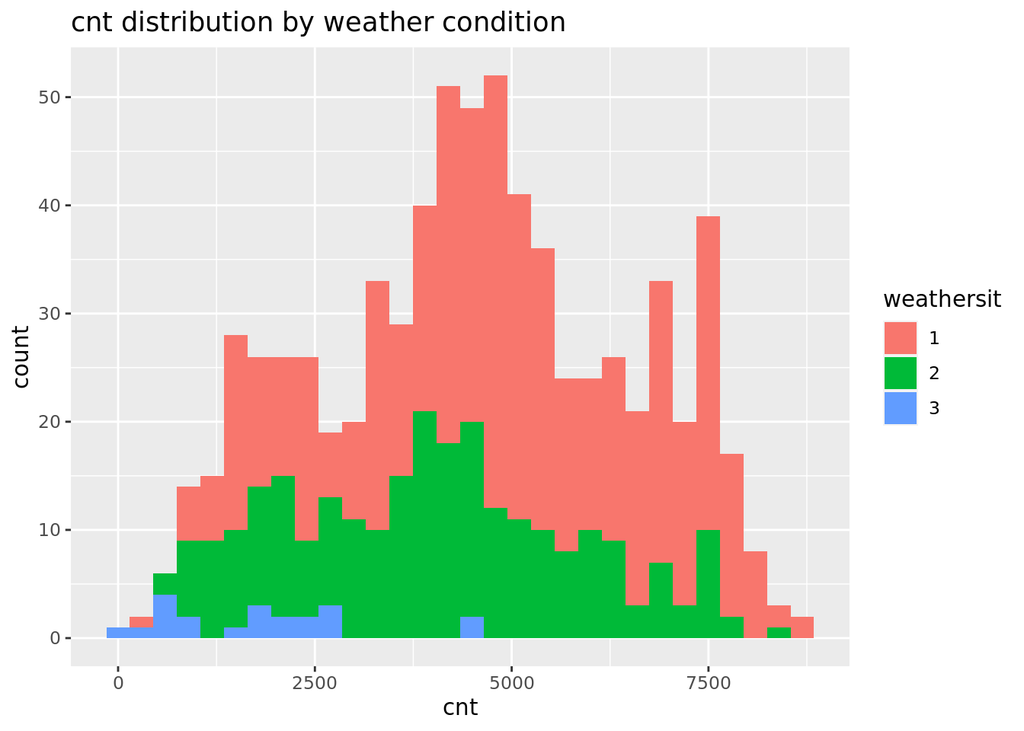

We could observe from the plot that, during the two years, most weather conditions are level 1 and 2, i.e, **Clear, Few clouds, Partly cloudy, Partly cloudy** and **Mist + Cloudy, Mist + Broken clouds, Mist + Few clouds, Mist**, only few of in level 3:**Light Snow, Light Rain + Thunderstorm + Scattered clouds, Light Rain + Scattered clouds**. More than that, rental bike count under weather condition level 3 all lies in smaller interval.

Below is the rental bike count plot by weekday:

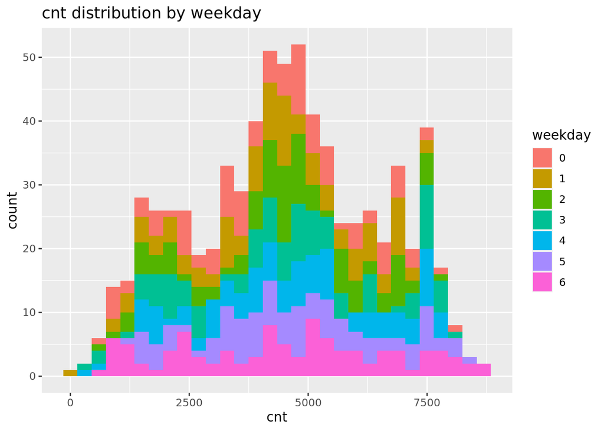

There is not a clearly unbalanced trend between different weekday level, the rental bike count across all weekday levels are equally distributed. This illustrate that weekday might not be a significant factor of rental bike count.

Below is the scatter plot of Rental Bike Count vs Temperature:

[figure not shown]

We can see there is clear positive relationship between rental bike count and temperature. Rental bike count may increase with the increasing of temperature.

Below is the scatter plot of Rental Bike Count vs Humidity:

[figure not shown]

Below is the scatter plot of Rental Bike Count vs Wind Speed:

[figure not shown]

#### Missing value check and redundant variables removal

Checking through both the dataset, there is no missing values, meaning we do not need any imputation step.

I observe that interested response equals registered user count plus casual user count, for better model fitting, I decided to remove these two attributes from latter analysis. Also, instant and dteday are just index and date recorded, also remove them.

Some numerical attributes(temperature, feeeling temperature, humidity and wind speed) in the dataset were given normalized and to make better understanding of our latter estimated coefficients, we need first normalized back those values to their original values.

- temperature: multiply by 41
- feeling temperature: multiply by 50
- humility: multiply by 100
- wind speed: multiply by 67

More than that, some variables like *season* has 4 levels and their read-in type is int, so we need to factor those categorical variable for latter model fitting.

## Methods and Results

Involved methodologies are: lasso regression, random forest, linear regression. For the first two methods, I mainly used for finding the features importance and results mainly based on the linear regression model.

I use 80% of original dataset for training and left 20% for test.

#### Lasso

Through adding a penalty, Lasso mainly used for shrunk some small parameters to zero such that prevent over-fitting and also could improve interpretability, especially for those models with too many variables. Here I use “cv.glmnet()” function to do cross validation to find the best lambda(penalty)–lambda.min which minimizes the cross validation error and also the lambda.1se which is considerably more conservative, gives larger penalty and more shrinkage.

Below is the output parameters after shrunkage by lambda.min(left) and lambda.1se(right).

```
## 12 x 2 sparse Matrix of class "dgCMatrix"
##                     s1          s1
## (Intercept) 1246.60002 1032.128853
## season       454.86448  323.155364
## yr          2043.89329 1888.358653
## mnth         -22.30379    .
## holiday     -263.80674    .
## weekday       74.76192   29.361252
## workingday   153.64726    .
## weathersit  -544.15304 -522.284206
## temp           .          .
## atemp        118.19977  111.270259
## hum          -11.89555   -2.509661
## windspeed    -30.94972  -11.334550
```

#### Random Forest

Random forest is a machine learning model which could fit many parallel CARTs (Classification And Regression Tree). In each CART, the data would be sample with replacement randomly and the features used in each CART would also be randomly selected. At the end, the majority voting would be selected as the final prediction/classification result. The number of features to be selected at each internal nodel and the stop point sample count number is crucial, thus I first used a grid of mty=c(4,6,8) and nodesize=(1,5,10,15,20) to tune these parameters and find out that mtry = 6, node size =1 give lowest MSE. Thus the final RF model is mtry = 6, node size =1, below is the importance table:

```
##               %IncMSE IncNodePurity
## season      34.107938     174460029
## yr         160.506706     605733879
## mnth        28.712572      96796872
## holiday     -1.248829       4686676
## weekday     10.532343      33598944
## workingday   5.468526       9521703
## weathersit  20.843536      47523853
## temp        24.281968     532886170
## atemp       27.218479     483308994
## hum         34.653882     137228753
## windspeed   14.842025      67554486
```

#### Linear Regression

Linear regression model is built to minimize the Residual Sum of Squares(RSS). It is simple but powerful. I first used Best Subset Selection to find the best model which gives minimum AIC/BIC/Marrow’s Cp value. Below is the visulization plot:

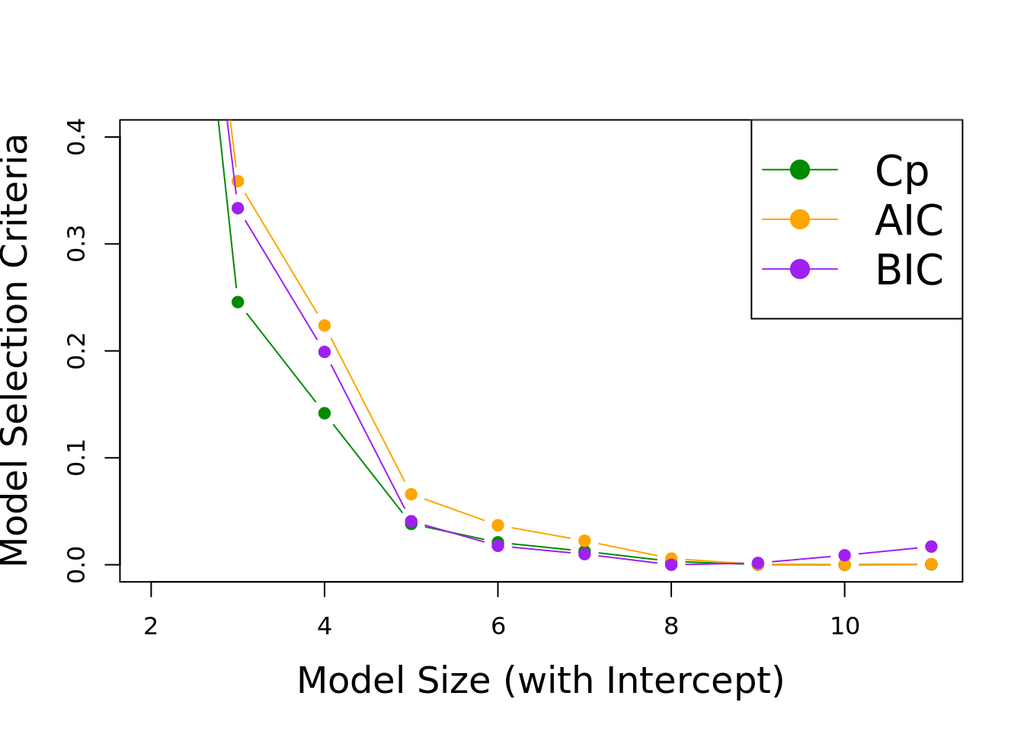

```
## Subset selection object
## 11 Variables  (and intercept)
##            Forced in Forced out
## season         FALSE      FALSE
## yr             FALSE      FALSE
## mnth           FALSE      FALSE
## holiday        FALSE      FALSE
## weekday        FALSE      FALSE
## workingday     FALSE      FALSE
## weathersit     FALSE      FALSE
## temp           FALSE      FALSE
## atemp          FALSE      FALSE
## hum            FALSE      FALSE
## windspeed      FALSE      FALSE
## 1 subsets of each size up to 10
## Selection Algorithm: exhaustive
##           season yr  mnth holiday weekday workingday weathersit temp atemp hum
## 1  ( 1 )  " "    " " " "  " "     " "     " "        " "        " "  "*"   " "
## 2  ( 1 )  " "    "*" " "  " "     " "     " "        " "        " "  "*"   " "
## 3  ( 1 )  "*"    "*" " "  " "     " "     " "        " "        " "  "*"   " "
## 4  ( 1 )  "*"    "*" " "  " "     " "     " "        "*"        " "  "*"   " "
## 5  ( 1 )  "*"    "*" " "  " "     "*"     " "        "*"        " "  "*"   " "
## 6  ( 1 )  "*"    "*" " "  " "     "*"     " "        "*"        " "  "*"   " "
## 7  ( 1 )  "*"    "*" " "  " "     "*"     " "        "*"        " "  "*"   "*"
## 8  ( 1 )  "*"    "*" " "  " "     "*"     "*"        "*"        " "  "*"   "*"
## 9  ( 1 )  "*"    "*" "*"  " "     "*"     "*"        "*"        " "  "*"   "*"
## 10  ( 1 ) "*"    "*" "*"  " "     "*"     "*"        "*"        "*"  "*"   "*"
##           windspeed
## 1  ( 1 )  " "
## 2  ( 1 )  " "
## 3  ( 1 )  " "
## 4  ( 1 )  " "
## 5  ( 1 )  " "
## 6  ( 1 )  "*"
## 7  ( 1 )  "*"
## 8  ( 1 )  "*"
## 9  ( 1 )  "*"
## 10  ( 1 ) "*"
```

Based on the plot we see that best model may contains 8 or 9 parameters(include intercept), here I choose 8. Then based on the Selection Algorithm plot, the kept features would be: **season, yr, weekday, weathersit, atemp(feeling temp), humidity, windspeed**.

## Conclusions

Below is the Mean Squared Error(MSE) calculated from the three models:

```
##               [,1]
## MSE_lasso 743810.5
## MSE_rf    496303.7
## MSE_lr    703279.4
```

We can see that random forest model gives lowest MSE, but we could not find out specific coefficients of random forest, so we pick the second lowest model to display the coefficients and make interpretations for reference only.

The final model(linear regression model) would be:

$$Bike Count \sim
season+yr+weekday+weathersit+atemp+hum+windspeed$$
;

Below is the summary statistics of these involved coefficients:

```
##               Estimate Std. Error   t value      Pr(>|t|)
## (Intercept) 1345.48986 254.629048  5.284118  1.793478e-07
## season       398.32329  36.059937 11.046145  7.263931e-26
## yr          2047.26671  73.787397 27.745479 2.730601e-108
## weekday       79.36898  18.233240  4.352983  1.588806e-05
## weathersit  -524.56401  93.711503 -5.597648  3.362551e-08
## atemp        119.91053   4.889275 24.525218  1.543787e-91
## hum          -13.07610   3.754758 -3.482541  5.342918e-04
## windspeed    -32.03029   7.582475 -4.224253  2.785637e-05
```

From the output estimated coefficients we can see that, most factors effect agree with what we observe in the histogram and scatter plots. Year contributes the most to the rental bike count, this may because that rental bike system being more popularize year by year and more people know this system and start use it. Also, season is also an important factor, people tend to spend less time outside during hot summer and cold winter, so they choose to rent a bike to speed their step. For severe weather, people might not go outside as frequent as good weather and thus less bike being rent during that time. One thing need to take more consideration is temperature, I believe it is more related to season while cannot find out the relationship right now.

## Suggestions

More than that, maybe try other methods to find out coefficients for more precise models, which could give better understanding of those factor effects.